# Resampling and Randomization

# Bootstrapping for Confidence Intervals

This is our first, and perhaps most common, application of resampling: generating a 95% confidence interval for any statistic.

As we discussed, we need this because we often want a CI for statistics (like the median or R-squared) that have no simple, reliable formula. The bootstrap lets us bypass this “no formula” problem by using computation to build the sampling distribution ourselves.

The goal of the bootstrap is to simulate the process of “going out and getting 10,000 new samples from the population” to see how much our statistic would vary.

## The Bootstrap Algorithm (Step-by-Step)

The algorithm to generate a bootstrap confidence interval is powerful, and surprisingly simple. It always follows the same four steps.

- **Start:** Begin with your original sample of data (of size n). This is your best guess for the “population.”
- **Initialize:** Create an empty vector (or list) to store the results of your simulation.
- **Loop (Simulate):** Repeat a large number of times (e.g., 10,000):
  - **a. Resample:** Draw a new “bootstrap sample” of size n from your original sample, WITH replacement (replace = TRUE).
  - **b. Calculate:** On this new bootstrap sample, calculate your statistic of interest (e.g., median(), mean(), or an lm() coefficient).
  - **c. Store:** Save that single statistic to your results vector.

Finish: You now have a vector of 10,000 statistics. This is your bootstrap sampling distribution.

```r
# Load the tidyverse for data manipulation
library(tidyverse)

# --- 1. Start ---
# Our original, small, skewed dataset
set.seed(456)
n_small <- 8
our_data <- rlnorm(n_small, meanlog = 2.0, sdlog = 1)
print("Our original data:")
```

```
## [1] "Our original data:"
```

```r
print(round(our_data, 1))
```

```
## [1]  1.9 13.8 16.5  1.8  3.6  5.3 14.7  9.5
```

```r
# Our point estimate
print(paste("Our observed median:", round(median(our_data), 2)))
```

```
## [1] "Our observed median: 7.42"
```

```r
# --- 2. Initialize ---
# Create an empty vector to store 10,000 medians
n_boot <- 10000
boot_medians <- numeric(n_boot)

# --- 3. Loop ---
# We set the seed again for reproducibility
set.seed(123)
for (i in 1:n_boot) {

  # a. Resample our data WITH replacement
  boot_sample <- sample(our_data, size = n_small, replace = TRUE)

  # b. Calculate the median on the new sample
  current_median <- median(boot_sample)

  # c. Store the result
  boot_medians[i] <- current_median
}

# --- 4. Finish ---
# Let's look at the first 10 results
print("First 10 bootstrapped medians:")
```

```
## [1] "First 10 bootstrapped medians:"
```

```r
print(round(head(boot_medians, 10), 2))
```

```
##  [1] 14.25  5.34  2.77 11.63  4.48 11.63 12.12  4.48  3.62 11.63
```

We now have boot_medians, a vector containing 10,000 plausible medians that we could have gotten if we had resampled from our population.

### From Bootstrap Distribution to Confidence Interval

That vector of 10,000 medians is the sampling distribution. It represents the full range of plausible variation for our statistic. We can visualize it with a histogram to see what it looks like.

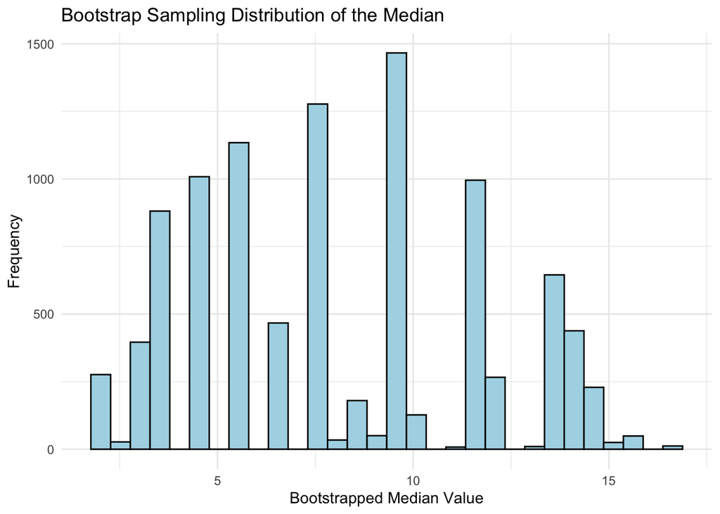

```r
# We'll put our results in a data frame for plotting with ggplot
boot_results_df <- data.frame(medians = boot_medians)

ggplot(boot_results_df, aes(x = medians)) +
  geom_histogram(bins = 30, fill = "lightblue", color = "black") +
  theme_minimal() +
  labs(
    title = "Bootstrap Sampling Distribution of the Median",
    x = "Bootstrapped Median Value",
    y = "Frequency"
  )
```

Now that we have this distribution, getting a 95% confidence interval is incredibly easy. We no longer need any complex formulas or t-tables.

A 95% confidence interval is simply the “middle 95%” of this distribution. To find it, we just need to find the value that cuts off the bottom 2.5% and the value that cuts off the top 2.5%.

We do this in R using the quantile() function.

```r
# Get the 95% confidence interval
boot_ci <- quantile(boot_medians, probs = c(0.025, 0.975))

print(boot_ci)
```

```
##      2.5%     97.5%
##  1.927991 14.741151
```

And that’s it! We can now state with 95% confidence that the true median of the population is likely between 1.93 and 14.74.

The key takeaway is this: This 4-step algorithm is universal.

You can swap out median() for any other statistic.

- Want a CI for the mean? Use mean(boot_sample).
- Want a CI for R-squared? Use summary(lm(y ~ x, data = boot_df))$r.squared.
- Want a CI for a regression coefficient? Use coef(lm(y ~ x, data = boot_df))[2].

The logic remains the same. This is why bootstrapping is one of the most powerful and flexible tools in modern statistics.

# Permutation Tests for p-values

In the last section, we used bootstrapping to create confidence intervals. The core idea was to simulate “plausible variation” by resampling with replacement. Now, we shift our focus to p-values. To get a p-value, we need to answer a different question: “How likely is the effect I saw, if there was no real effect at all?”

We are no longer simulating plausible variation; with permutation, we are attempting to simulate a world where the null hypothesis is true. The core idea is this: if the null hypothesis is true, then the labels we assign to our data (e.g., “Drug” vs. “Placebo”, or “Group A” vs. “Group B”, etc.) are meaningless. If the labels are meaningless, we should be able to shuffle them (i.e., permute them) and get a similar result just by random chance. This leads to a powerful new algorithm.

Let’s trace the full algorithm for testing the difference in means between two groups, “A” and “B”.

- **Start:** Begin with your two groups (e.g., group_a_outcomes and group_b_outcomes).
- **Calculate Observed Statistic:** First, calculate the real difference in means from your actual data. This is the one true value you are testing against.
- **Initialize:** Create an empty vector (e.g., null_results) to store the results of your simulation.Loop (Simulate):
- **Repeat 10,000 times:**
  - **a. Pool:** Combine all outcome scores from both groups into one large vector.
  - **b. Shuffle (Permute):** Create a new set of “fake” group labels by shuffling the original labels. This is like randomly dealing all the “A” and “B” labels back to the pooled data.
  - **c. Assign:** Create your new “fake_A” and “fake_B” groups based on these randomly shuffled labels.
  - **d. Calculate:** Calculate the difference in means for these new, fake groups (e.g., mean(fake_A) - mean(fake_B)).e.
  - **Store:** Save this “null” statistic to your null_results vector.
- **Finish:** You now have a vector of 10,000 “null” statistics. This is your null distribution.

**From Null Distribution to p-value:** This null_results vector is critical. It’s a distribution of 10,000 “differences-in-means” that could have been produced by random chance alone. It’s centered at 0, because we’d expect the difference to be zero, on average, if the labels are meaningless. To get our p-value, we just compare our one observed statistic from Step 2 to this null distribution. The p-value is the proportion of our 10,000 null statistics that were at least as extreme as our one observed statistic. Let’s run a quick example.

```r
# --- 1. Start ---
# We'll use the ToothGrowth data
data("ToothGrowth")
group_a <- ToothGrowth$len[ToothGrowth$supp == "OJ"]
group_b <- ToothGrowth$len[ToothGrowth$supp == "VC"]

# --- 2. Calculate Observed Statistic ---
observed_diff <- mean(group_a) - mean(group_b)
print(paste("Observed Difference in Means:", round(observed_diff, 2)))
```

```
## [1] "Observed Difference in Means: 3.7"
```

```r
# --- 3. Initialize ---
n_perm <- 10000
null_diffs <- numeric(n_perm)
all_outcomes <- c(group_a, group_b)
all_labels   <- ToothGrowth$supp

# --- 4. Loop ---
set.seed(123) # for reproducibility
for (i in 1:n_perm) {
  # b. Shuffle the labels
  shuffled_labels <- sample(all_labels)

  # c/d. Calculate mean difference for this "fake" world
  fake_mean_a <- mean(all_outcomes[shuffled_labels == "OJ"])
  fake_mean_b <- mean(all_outcomes[shuffled_labels == "VC"])

  # e. Store the null statistic
  null_diffs[i] <- fake_mean_a - fake_mean_b
}

# --- 5. Calculate p-value ---
# How many of the null differences are as extreme as our observed difference?
# We use abs() for a two-tailed test
p_value <- mean(abs(null_diffs) >= abs(observed_diff))
print(paste("Permutation p-value:", p_value))
```

```
## [1] "Permutation p-value: 0.0587"
```

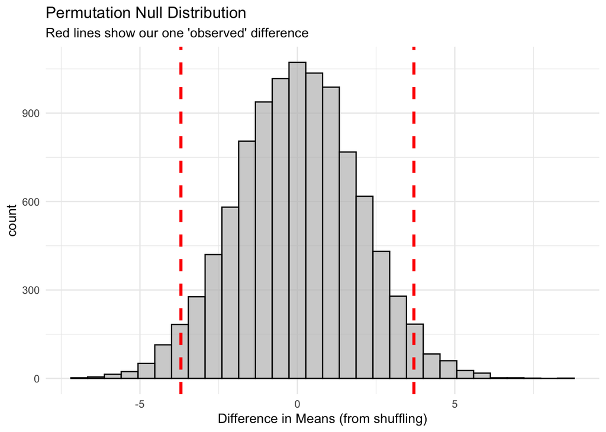

```r
# Let's plot the null distribution and our observed value
null_dist_df <- data.frame(differences = null_diffs)
ggplot(null_dist_df, aes(x = differences)) +
  geom_histogram(bins = 30, fill = "gray", color = "black", alpha = 0.7) +
  geom_vline(xintercept = observed_diff, color = "red", linewidth = 1.2, linetype = "dashed") +
  geom_vline(xintercept = -observed_diff, color = "red", linewidth = 1.2, linetype = "dashed") +
  labs(title = "Permutation Null Distribution",
       subtitle = "Red lines show our one 'observed' difference",
       x = "Difference in Means (from shuffling)") +
  theme_minimal()
```

Our calculated p-value is the proportion of the gray histogram bars that fall to the outside of the two dashed red lines. This tells us how often a difference as large as our observed difference would pop up just by random chance.

This logic isn’t just for t-tests. It can be applied to almost any model, including lm() models. How do you test the p-value for lm(y ~ x) where the null Hypothesis ($H_0$) is that the relationship between x and y is zero? If $H_0$ is true, then the (x, y) pairings in our data are just a coincidence. We can simulate this “un-related” world by breaking the link between them. The easiest way is to repeatedly shuffle the y vector.

**The Loop:** - Calculate your observed slope (coefficient) from lm(y ~ x). - Loop 10,000 times: - a. Create a shuffled_y vector by sample(y). - b. Run the null model: null_model <- lm(shuffled_y ~ x). - c. Store the slope: null_slopes[i] <- coef(null_model)[2].

You now have a null distribution of 10,000 slopes and your p-value is mean(abs(null_slopes) >= abs(observed_slope)). This technique gives you a robust, assumption-free p-value for any predictor in your lm() model.

# nPutting It All Together (Bootstrap and Permutation)

Now it’s your turn. Use the ToothGrowth dataset to perform both a bootstrap and a permutation test. This will help you solidify the difference between the two methods.

## Exercise #1 - Bootstrapping

- Dataset: ToothGrowth (variables: len and supp)
- Objective: To find the 95% Confidence Interval for the difference in means between supp == “OJ” and supp == “VC”.

```r
# --- 1. Get the data ---
data("ToothGrowth")
group_oj <- ToothGrowth$len[ToothGrowth$supp == "OJ"]
group_vc <- ToothGrowth$len[ToothGrowth$supp == "VC"]

# --- 2. Initialize ---
n_boot <- 10000
boot_diffs <- numeric(n_boot)

# --- 3. Write your bootstrap loop ---
# HINT: You need to sample *with replacement* from group_oj
# and *separately* sample with replacement from group_vc.
for (i in 1:n_boot) {
  # boot_oj <- sample(...)
  # boot_vc <- sample(...)
  # boot_diffs[i] <- mean(boot_oj) - mean(boot_vc)
}

# --- 4. Plot your bootstrap distribution ---
# (Make a histogram of boot_diffs)

# --- 5. Calculate the 95% CI ---
# (Use the quantile() function on boot_diffs)

# --- 6. Compare to the t.test() ---
# classic_test <- t.test(len ~ supp, data = ToothGrowth)
# print(classic_test$conf.int)
```

Question: Compare your bootstrap CI to the one from t.test(len ~ supp). Are they similar? Why or why not?

## Exercise #2 - Permutation

- Dataset: ToothGrowth (variables: len and supp)
- Objective: To find the p-value for the difference in means between supp == “OJ” and supp == “VC”.

```r
# --- 1. Calculate your OBSERVED difference ---
# (You already have this from Task 1: mean(group_oj) - mean(group_vc))
observed_diff <- mean(group_oj) - mean(group_vc)

# --- 2. Initialize ---
n_perm <- 10000
null_diffs <- numeric(n_perm)
all_outcomes <- ToothGrowth$len
all_labels   <- ToothGrowth$supp

# --- 3. Write your permutation loop ---
# HINT: You need to sample *without replacement* (shuffle)
# the *all_labels* vector.
for (i in 1:n_perm) {
  # shuffled_labels <- sample(...)
  # fake_mean_oj <- mean(all_outcomes[shuffled_labels == "OJ"])
  # ...
  # null_diffs[i] <- ...
}

# --- 4. Plot your null distribution ---
# (Make a histogram of null_diffs and add a vline for observed_diff)

# --- 5. Calculate the p-value ---
# (Use the mean(abs(...) >= abs(...)) formula)

# --- 6. Compare to the t.test() ---
# classic_test <- t.test(len ~ supp, data = ToothGrowth)
# print(classic_test$p.value)
```

Question: Compare your permutation p-value to the one from t.test(len ~ supp). Are they similar?

# Cross-Validation (Resampling for Model Validation)

So far in this chapter, we’ve used resampling to understand our existing data. Bootstrapping let us get confidence intervals (CIs) to answer: “How uncertain is my statistic?” Permutation Tests let us get p-values to answer: “How likely is my result by chance?”

Now, we’ll learn the third and final member of the resampling “holy trinity”: Cross-Validation. This technique uses resampling to answer a completely different, and perhaps more important, question: “How well will my model work on new, unseen data?”

This section moves us from statistical inference (explaining what we have) to model validation and the first steps of machine learning (predicting what we haven’t seen).

## The Problem of Overfitting

In our module on linear models, we built models to explain the data we already had. For example, when we ran lm(dist ~ speed, data = cars), we got an R-squared of 0.65. This R-squared tells us how well our model’s line fits the 50 data points it was built with.

But there’s a problem: that 0.65 is overly optimistic. The lm() function is designed to find the single best possible line for those 50 points. It has perfectly “fit” itself to the unique quirks and random noise of our specific sample. If we were to gather 50 new data points and use our original model to make predictions, our R-squared on this new data would almost certainly be lower.

This is called overfitting. The model is “tuned” to our training data but won’t perform as well in the real world. The Key Question is, “How do we get an honest estimate of our model’s performance?”

The simplest method is the train/test split. You randomly divide your data, holding back 20% as a “test set.” You build your model on the 80% (“training set”) and then test it on the 20% to get an honest R-squared. The problem with this is that it’s inefficient (you “lose” 20% of your data for training) and your entire answer depends on the luck of which 20% you happened to pick for the test set.

**The Resampling Solution:** k-Fold Cross-Validation

Cross-validation (CV) solves this problem using a more clever resampling approach. Instead of one split, we do many splits and average the results. The most common method is k-fold cross-validation.

Here is the algorithm for 10-fold CV:

1. **Start:** Take your full dataset.
2. **Split:** Randomly shuffle and split the data into 10 equal “folds” (like 10 slices of a pie).
3. **Loop (Simulate):** Repeat 10 times (once for each fold):
1. Hold out: Use Fold 1 as your “test set” (the unseen data).
2. Train: Use the other 9 folds (Folds 2-10) as your “training set.”
3. Model: Build your lm(y ~ x) only on the 9-fold training set.
4. Predict: Use that newly trained model to make predictions on the held-out Fold 1.
5. Store: Calculate and store the performance metric (e.g., R-squared or RMSE) from that test.
4. Repeat: Now, hold out Fold 2 as the test set and train on Folds 1, 3-10. Then hold out Fold 3 and train on the rest, and so on, until every fold has been the “test set” exactly once.
5. Finish: You now have 10 “honest” performance scores. The average of these 10 scores is your final cross-validated R-squared. This is a much more robust and reliable estimate of how your model will perform on new data.

Let’s see this in action. We can build a 5-fold CV “engine” ourselves using a for loop. We’ll use the cars dataset

```r
library(tidyverse)

# 1. Add a "fold" ID to our data
# We'll use 5 folds for this example
data(cars)
set.seed(123) # for reproducibility
cars_folded <- cars %>%
  mutate(fold = sample(1:5, size = nrow(cars), replace = TRUE))

# 2. Initialize
# Create an empty vector to store our 5 R-squared values
fold_r2s <- numeric(5) # We have 5 folds

# 3. Loop
for (i in 1:5) {

  # a/b. Split into training and testing
  # The test data is just the data for the current fold 'i'
  test_data  <- cars_folded %>% filter(fold == i)

  # The training data is everything else
  train_data <- cars_folded %>% filter(fold != i)

  # c. Model: Build *only* on the training data
  model <- lm(dist ~ speed, data = train_data)

  # d. Predict: Test on the hold-out fold
  predictions <- predict(model, newdata = test_data)
  # note: The predict() function was written to use "newdata" instead of data to make it clear that you are passing in new observations, not the original data used to build the model.

  # e. Store R-squared from the *test* data
  # We have to calculate R-squared manually from the test predictions
  ss_total <- sum((test_data$dist - mean(test_data$dist))^2)
  ss_resid <- sum((test_data$dist - predictions)^2)
  fold_r2s[i] <- 1 - (ss_resid / ss_total)
}

# 5. Finish
print("R-squared from each of the 5 folds:")
```

```
## [1] "R-squared from each of the 5 folds:"
```

```r
print(round(fold_r2s, 3))
```

```
## [1] 0.594 0.278 0.624 0.577 0.651
```

```r
print(paste("Average Cross-Validated R-squared:", round(mean(fold_r2s), 3)))
```

```
## [1] "Average Cross-Validated R-squared: 0.545"
```

```r
# Compare this to the "overly optimistic" R-squared
optimistic_r2 <- summary(lm(dist ~ speed, data = cars))$r.squared
print(paste("Optimistic R-squared from the full dataset:", round(optimistic_r2, 3)))
```

```
## [1] "Optimistic R-squared from the full dataset: 0.651"
```

Together, these three techniques (Bootstrap, Permutation, Cross-Validation) form the “holy trinity” of modern computational statistics.

- Bootstrap (Inference) answers: “How uncertain is my statistic?” (Gives CIs)
- Permutation (Inference) answers: “How likely is my result by chance?” (Gives p-values)
- Cross-Validation (Prediction) answers: “How well will my model work on new data?” (Gives a model generalization error)